# Precision and recall analysis

Max Dippel

2023-09-12

The goal of this rmd is to get precision and recall heat maps to try and develop an imperical method to classify emvars.

Precision is the fraction of relevant instances divided by all retrieved instances. This is also called the positive predictive value. Precision = True Positives / (True Positives + False Positives)

Recall is the fraction of all retrieved instances divided by all the retrieved instances. This is also called the sensitivity. Recall = True Positives / (True Positives + False Negatives)

This html will give precision and recall plots for these parameters:

1. Skew
2. Max Allele Fold Change
3. Fold Change p-value with Benjamhini Hochberg correction
4. Fold Change p-value with Bonferroni correction

To calculate the true_positives and false_positives we use these thresholds:

True Positive: max_pics>=0.5

FalsePositive: max_pics<=0.001

# HTML version

This is the place in the html you can tell which mpra data set and specific filters are being used. In the Rmd there are multiple options and you need to delete “, eval=FALSE, echo=FALSE” from the R chunk you want to use. This will make that R chunk be used in the making of the html and display that code chunk in the html. To create the html with the correct mpra loading code chunk, you need to do to run the render chunk which is directly below it. Keep the render chunk ” eval=FALSE, Echo=FALSE” so it does not appear in the html.

```r
# This html version uses the mpra data from 20230518_GM12878_emVAR_glm_mpra_merge.txt
# This html version has the B-cell DHS filter
mpra.dir <- "/nfs/jray/screens/ALL_MPRAs/Ho_et_al_analysis/Downstream_Analysis/20230518_GM12878_emVAR_glm/data/20230518_GM12878_emVAR_glm_mpra_merge.txt"
mpra <- read.table(mpra.dir, sep="\t", header=T)
mpra_name <- "20230518_GM12878_emVAR_glm"
filter <- "DHS"
mpra <- subset(mpra, dhs_Bcell_merged>=1)
```

# Special Columns

This runs a loop to find the max fold changes.

```r
#For each MPRA variant, find the fold change of the allele with the largest absolute fold change
# This creates a column full of NAs for the loop to fill
mpra$max_abs_fc <- NA
# This loop calculates the column of max_abs_fc. It takes the two alleles A and B and calculates which one's absolute value is larger. That larger value is the value of the new column (can be positive or negative).
for(i in 1:nrow(mpra)){
  if(abs(mpra[i,]$A.log2FC)>abs(mpra[i,]$B.log2FC)){
    mpra[i,]$max_abs_fc<-mpra[i,]$A.log2FC
  }else{
    mpra[i,]$max_abs_fc<-mpra[i,]$B.log2FC
  }
}
```

This runs a loop to find the max fold change p values with the Benjamini Hochberg correction.

```r
#For each MPRA variant, find the fold change of the allele with the largest absolute fold change
# This creates a column full of NAs for the loop to fill
mpra$max.logPadj_BH<-NA
# This loop calculates the column of max_abs_fc. It takes the two alleles A and B and calculates which one's absolute value is larger. That larger value is the value of the new column (can be positive or negative).
for(i in 1:nrow(mpra)){
  if(abs(mpra[i,]$A.logPadj_BH)>abs(mpra[i,]$B.logPadj_BH)){
    mpra[i,]$max.logPadj_BH<-mpra[i,]$A.logPadj_BH
  }else{
    mpra[i,]$max.logPadj_BH<-mpra[i,]$B.logPadj_BH
  }
}
```

This runs a loop to find the max fold change p values with the bonferroni correction.

```r
#For each MPRA variant, find the fold change of the allele with the largest absolute fold change
# This creates a column full of NAs for the loop to fill
mpra$max.logPadj_BF<-NA
# This loop calculates the column of max_abs_fc. It takes the two alleles A and B and calculates which one's absolute value is larger. That larger value is the value of the new column (can be positive or negative).
for(i in 1:nrow(mpra)){
  if(abs(mpra[i,]$A.logPadj_BF)>abs(mpra[i,]$B.logPadj_BF)){
    mpra[i,]$max.logPadj_BF<-mpra[i,]$A.logPadj_BF
  }else{
    mpra[i,]$max.logPadj_BF<-mpra[i,]$B.logPadj_BF
  }
}
```

```r
#For each MPRA variant, find the pics for all the diseases and make max_pics the maximum of all of those values
mpra.pics <- subset(mpra, select=c(MS_pics,RA_pics,UC_pics,T1D_pics,IBD_pics,Crohns_pics,Psoriasis_pics))

# Make the NAs for pics -1
mpra.pics$MS_pics[is.na(mpra.pics$MS_pics)]<- (-1)
mpra.pics$RA_pics[is.na(mpra.pics$RA_pics)]<- (-1)
mpra.pics$UC_pics[is.na(mpra.pics$UC_pics)]<- (-1)
mpra.pics$IBD_pics[is.na(mpra.pics$IBD_pics)]<- (-1)
mpra.pics$T1D_pics[is.na(mpra.pics$T1D_pics)]<- (-1)
mpra.pics$Crohns_pics[is.na(mpra.pics$Crohns_pics)]<- (-1)
mpra.pics$Psoriasis_pics[is.na(mpra.pics$Psoriasis_pics)]<- (-1)
colnames(mpra.pics)
```

```
## [1] "MS_pics"        "RA_pics"        "UC_pics"        "T1D_pics"       "IBD_pics"       "Crohns_pics"    "Psoriasis_pics"
```

```r
mpra.pics$win_pics <- colnames(mpra.pics)[apply(mpra.pics,1,which.max)] # Make a column that is called win_pics which will give me the name of the pics column with the best

mpra.pics$max_pics <- NA # This creates a column full of NAs for the loop to fill

for(i in 1:nrow(mpra.pics)){
  if(mpra.pics[i,]$win_pics=="MS_pics"){
    mpra.pics[i,]$max_pics<-mpra.pics[i,]$MS_pics
  } # if win_pics says MS_pics then the max_pics is MS_pics
  if(mpra.pics[i,]$win_pics=="RA_pics"){
    mpra.pics[i,]$max_pics<-mpra.pics[i,]$RA_pics
  } # if win_pics says RA_pics then the max_pics is RA_pics
  if(mpra.pics[i,]$win_pics=="UC_pics"){
    mpra.pics[i,]$max_pics<-mpra.pics[i,]$UC_pics
  } # if win_pics says UC_pics then the max_pics is UC_pics
  if(mpra.pics[i,]$win_pics=="IBD_pics"){
    mpra.pics[i,]$max_pics<-mpra.pics[i,]$IBD_pics
  } # if win_pics says IBD_pics then the max_pics is IBD_pics
  if(mpra.pics[i,]$win_pics=="Crohns_pics"){
    mpra.pics[i,]$max_pics<-mpra.pics[i,]$Crohns_pics
  } # if win_pics says Crohns_pics then the max_pics is Crohns_pics
  if(mpra.pics[i,]$win_pics=="Psoriasis_pics"){
    mpra.pics[i,]$max_pics<-mpra.pics[i,]$Psoriasis_pics
  } # if win_pics says Psoriasis_pics then the max_pics is Psoriasis_pics
   if(mpra.pics[i,]$win_pics=="T1D_pics"){
    mpra.pics[i,]$max_pics<-mpra.pics[i,]$T1D_pics
  } # if win_pics says T1D_pics then the max_pics is T1D_pics
}

# Make the MPRA pics columns which are NA return to NA
mpra.pics$MS_pics[mpra.pics$MS_pics<0]<- NA
mpra.pics$RA_pics[mpra.pics$RA_pics<0]<- NA
mpra.pics$UC_pics[mpra.pics$UC_pics<0]<- NA
mpra.pics$IBD_pics[mpra.pics$IBD_pics<0]<- NA
mpra.pics$T1D_pics[mpra.pics$T1D_pics<0]<- NA
mpra.pics$Crohns_pics[mpra.pics$Crohns_pics<0]<- NA
mpra.pics$Psoriasis_pics[mpra.pics$Psoriasis_pics<0]<- NA
```

```r
mpra$max_pics <- mpra.pics$max_pics
```

How many variants in this version of MPRA have a maximum pics value of greater than or equal to 0.5

```r
nrow(subset(mpra, max_pics>=0.5))
```

```
## [1] 32
```

# Precision and Recall Plots

Skew heat map.

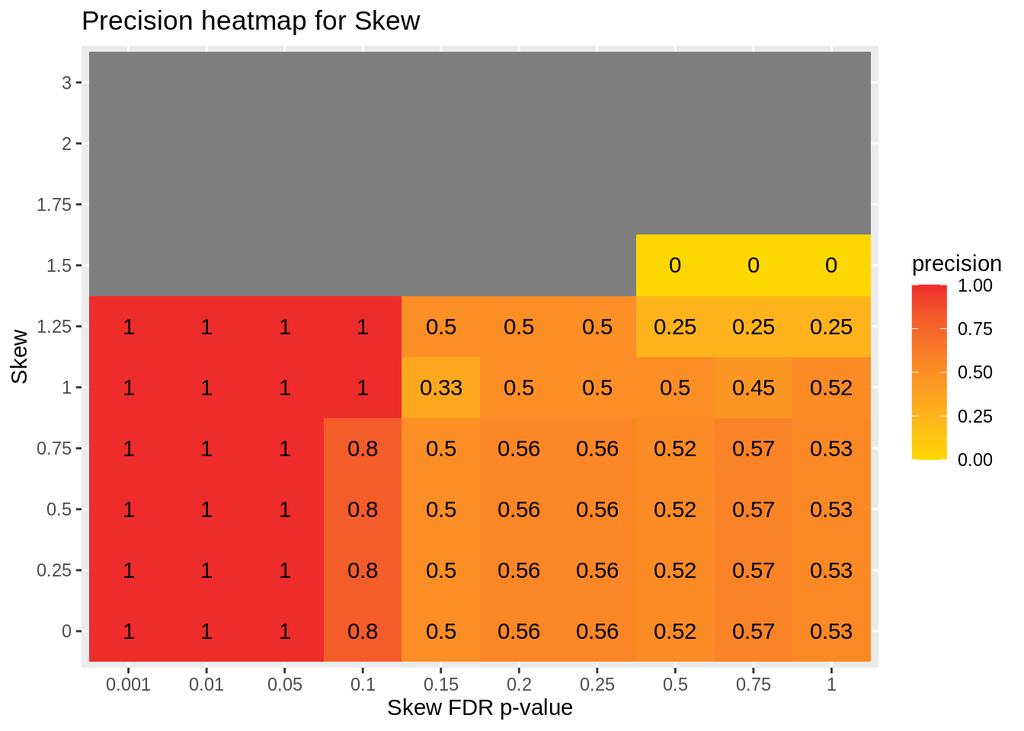

```r
skew_seq <-c(0, 0.25, 0.5, 0.75, 1, 1.25, 1.5, 1.75, 2, 3)
FDR_seq <-c(0.001, 0.01, 0.05, 0.1, 0.15, 0.2, 0.25, 0.5, 0.75, 1)
precision.skew.dat <- NULL
for( i in FDR_seq){
  for(j in skew_seq){
   mpra_subset <- subset(mpra, select=c(Skew.logFDR,LogSkew,max_abs_fc,max.logPadj_BH,max.logPadj_BF,max_pics)) # subset the mpra to only the columns we want.
   all_true <- nrow(subset(mpra_subset, max_pics>=0.5)) #all true in that they are all likely causal according to statistical fine-mapping. This measurement is the true positives and false negatives (which are truely positive). All true goes into the denominator of precision.
   mpra_subset$SkewFDR<- 10^-mpra_subset$Skew.logFDR # undo the negative log transformation of the Skew log p-values and create the column SkewFDR
   mpra_subset$Skew<- 2^mpra_subset$LogSkew # undo the log transformation of logSkew to create a column called skew
   true_positive <- nrow(subset(mpra_subset, SkewFDR <= i & Skew >= j & max_pics>=0.5)) # This variable are the true positives. They are emVars which meet the specific requirements of each variable and are positive pics values (meaning they are truly significant). This is in the numerator in both precision and recall.
   false_positive <- nrow(subset(mpra_subset, SkewFDR <= i & Skew >= j & max_pics<=0.001)) # This variable is false positives. They are the non-Emvars which meet the specific requirements of the skew and SkewFDR and have the poor pics values. This is part of the denominator in precision.
   precision <- true_positive/(true_positive+false_positive) # Precision is calculated by True Positives / (True Positives + False Positives).
   recall <- true_positive/all_true # Recall is calculated as True Positives / (True Positives + False Negatives). All True is True Positives + False Negatives (which are actually true)
   precision.skew.dat <- rbind(precision.skew.dat, data.frame(i, j, precision, recall, all_true, true_positive, false_positive)) # makes the dataframe used for the heat map
  }
}
names(precision.skew.dat) <- c("FDR", "Skew", "precision", "recall", "all_true", "true_positive", "false_positive")

ggplot(data.frame(precision.skew.dat), aes(x = as.character(FDR), y = as.character(Skew), fill = precision)) +
  geom_tile() + geom_text(aes(label = round(precision, digit=2))) + xlab("Skew FDR p-value") + ylab("Skew") +
  ggtitle("Precision heatmap for Skew") + scale_fill_gradient(low = "gold", high = "firebrick2")
```

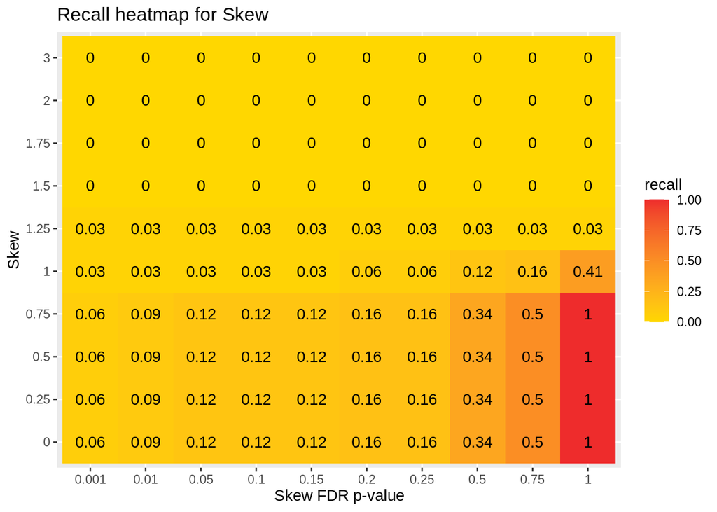

```r
ggplot(data.frame(precision.skew.dat), aes(x = as.character(FDR), y = as.character(Skew), fill = recall)) +
  geom_tile() + geom_text(aes(label = round(recall, digit=2))) + xlab("Skew FDR p-value") + ylab("Skew") +
  ggtitle("Recall heatmap for Skew") + scale_fill_gradient(low = "gold", high = "firebrick2")
```

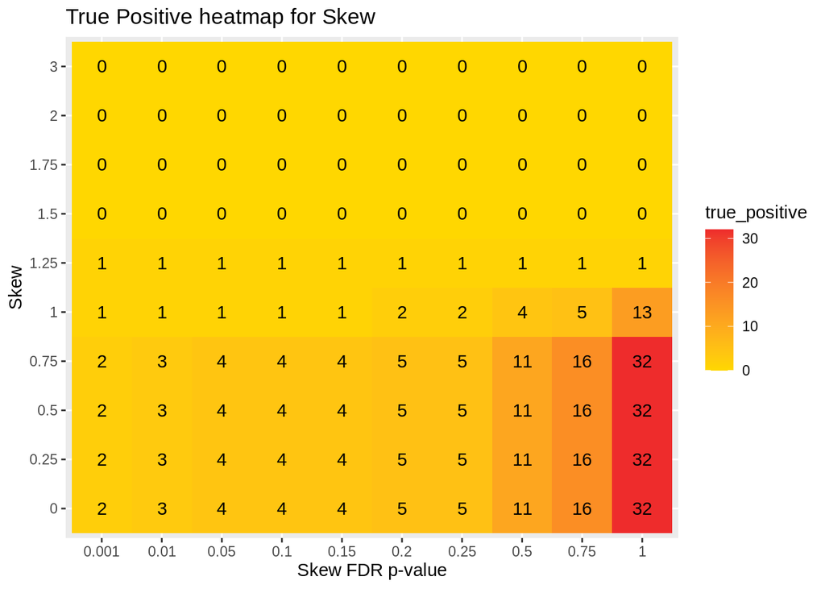

```r
ggplot(data.frame(precision.skew.dat), aes(x = as.character(FDR), y = as.character(Skew), fill = true_positive)) +
  geom_tile() + geom_text(aes(label = round(true_positive, digit=2))) + xlab("Skew FDR p-value") + ylab("Skew") +
  ggtitle("True Positive heatmap for Skew") + scale_fill_gradient(low = "gold", high = "firebrick2")
```

Now attempt to create a heat map for maximum absolute fold change

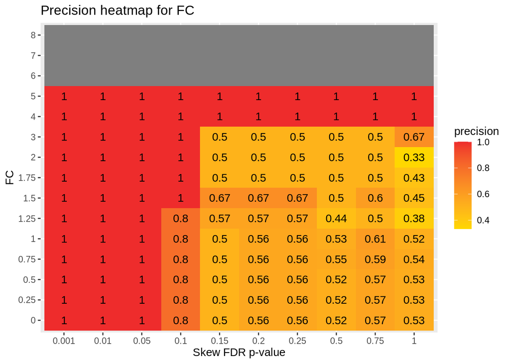

```r
skew_seq <-c(0, 0.25, 0.5, 0.75, 1, 1.25, 1.5, 1.75, 2, 3, 4, 5, 6, 7, 8)
FDR_seq <-c(0.001, 0.01, 0.05, 0.1, 0.15, 0.2, 0.25, 0.5, 0.75, 1)
precision.FC.dat <- NULL
for( i in FDR_seq){
  for(j in skew_seq){
   mpra_subset <- subset(mpra, select=c(Skew.logFDR,LogSkew,max_abs_fc,max.logPadj_BH,max.logPadj_BF,max_pics)) # subset the mpra to only the columns we want.
   all_true <- nrow(subset(mpra_subset, max_pics>=0.5)) #all true in that they are all likely causal according to statistical fine-mapping. This measurement is the true positives and false negatives (which are truely positive). All true goes into the denominator of precision.
   mpra_subset$SkewFDR<- 10^-mpra_subset$Skew.logFDR # undo the negative log transformation of the Skew log p-values and create the column SkewFDR
   mpra_subset$FC<- 2^mpra_subset$max_abs_fc # undo the log transformation of log 2 fold change to create a column called FC
   true_positive <- nrow(subset(mpra_subset, SkewFDR <= i & FC >= j & max_pics>=0.5)) # This variable are the true positives. They are emVars which meet the specific requirements of each variable and are positive pics values (meaning they are truly significant). This is in the numerator in both precision and recall.
   false_positive <- nrow(subset(mpra_subset, SkewFDR <= i & FC >= j & max_pics<=0.001)) # This variable is false positives. They are the non-Emvars which meet the specific requirements of the FC and SkewFDR and have the poor pics values. This is part of the denominator in precision.
   # sampled_false_positive<-false_positive[sample(nrow(false_positive), size=true_positive),]
   # we are not going to sample the false positives in these plots
   precision <- true_positive/(true_positive+false_positive) # Precision is calculated by True Positives / (True Positives + False Positives).
   recall <- true_positive/all_true # Recall is calculated as True Positives / (True Positives + False Negatives). All True is True Positives + False Negatives (which are actually true)
   precision.FC.dat <- rbind(precision.FC.dat, data.frame(i, j, precision, recall, all_true, true_positive, false_positive)) # makes the dataframe used for the heat map
  }
}
names(precision.FC.dat) <- c("FDR", "FC", "precision", "recall", "all_true", "true_positive", "false_positive")

ggplot(data.frame(precision.FC.dat), aes(x = as.character(FDR), y = as.character(FC), fill = precision)) +
  geom_tile() + geom_text(aes(label = round(precision, digit=2))) + xlab("Skew FDR p-value") + ylab("FC") +
  ggtitle("Precision heatmap for FC") + scale_fill_gradient(low = "gold", high = "firebrick2")
```

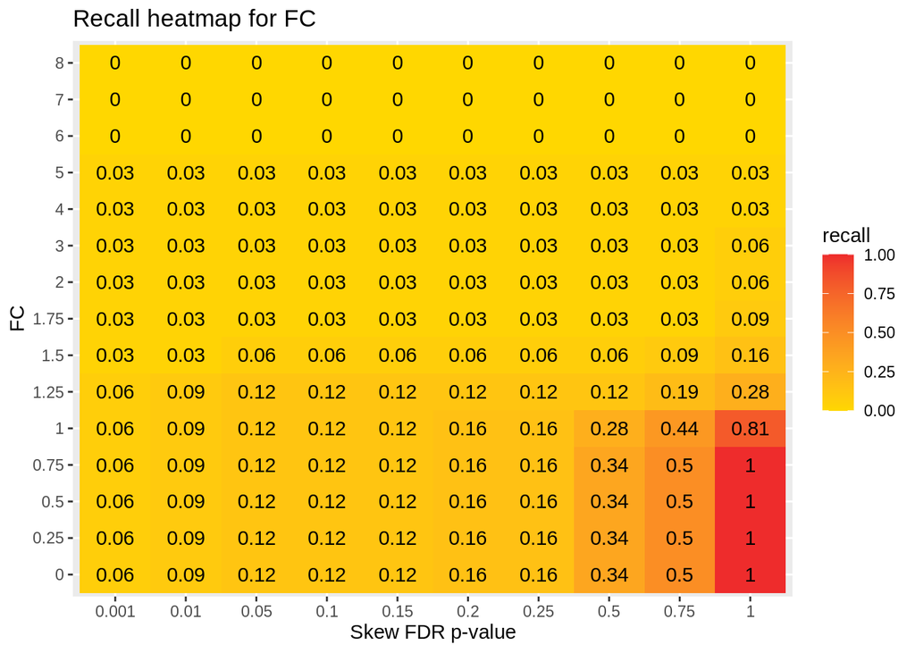

```r
ggplot(data.frame(precision.FC.dat), aes(x = as.character(FDR), y = as.character(FC), fill = recall)) +
  geom_tile() + geom_text(aes(label = round(recall, digit=2))) + xlab("Skew FDR p-value") + ylab("FC") +
  ggtitle("Recall heatmap for FC") + scale_fill_gradient(low = "gold", high = "firebrick2")
```

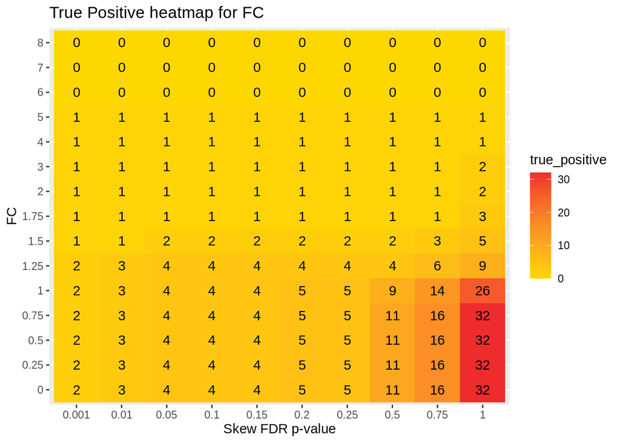

```r
ggplot(data.frame(precision.FC.dat), aes(x = as.character(FDR), y = as.character(FC), fill = true_positive)) +
  geom_tile() + geom_text(aes(label = round(true_positive, digit=2))) + xlab("Skew FDR p-value") + ylab("FC") +
  ggtitle("True Positive heatmap for FC") + scale_fill_gradient(low = "gold", high = "firebrick2")
```

Heat map for BH p-values

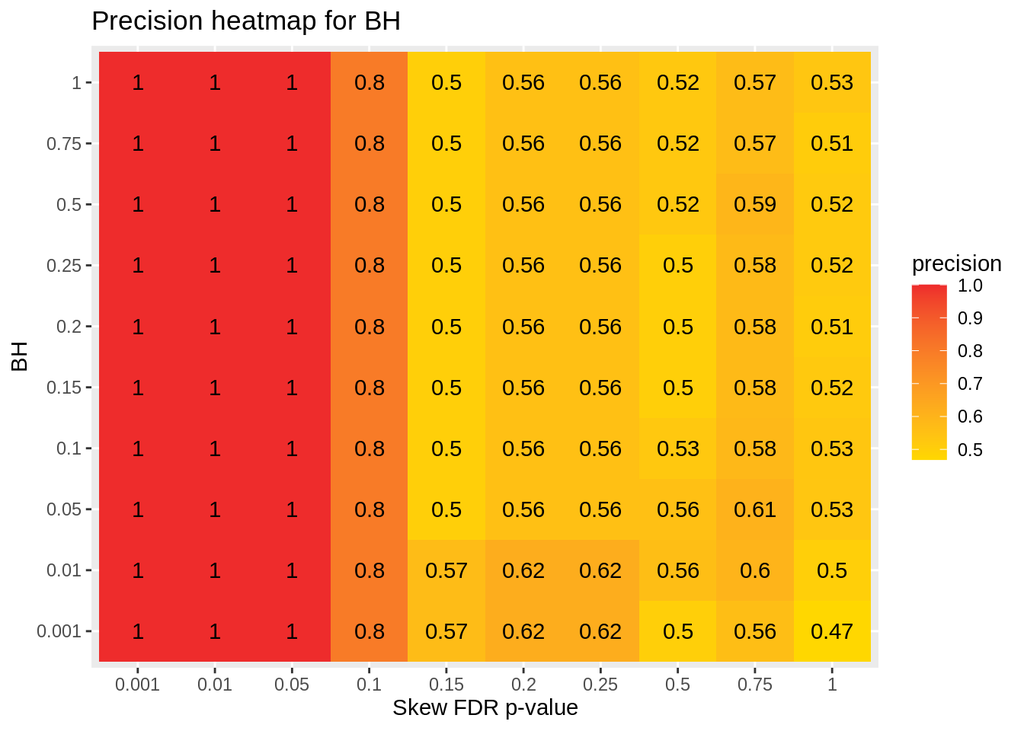

```r
BH_seq <-c(0.001, 0.01, 0.05, 0.1, 0.15, 0.2, 0.25, 0.5, 0.75, 1)
FDR_seq <-c(0.001, 0.01, 0.05, 0.1, 0.15, 0.2, 0.25, 0.5, 0.75, 1)
precision.BH.dat <- NULL
for( i in FDR_seq){
  for(j in BH_seq){
   mpra_subset <- subset(mpra, select=c(Skew.logFDR,LogSkew,max_abs_fc,max.logPadj_BH,max.logPadj_BF,max_pics)) # subset the mpra to only the columns we want.
   all_true <- nrow(subset(mpra_subset, max_pics>=0.5)) #all true in that they are all likely causal according to statistical fine-mapping. This measurement is the true positives and false negatives (which are truely positive). All true goes into the denominator of precision.
   mpra_subset$SkewFDR<- 10^-mpra_subset$Skew.logFDR # undo the negative log transformation of the Skew log p-values and create the column SkewFDR
   mpra_subset$BH<- 10^-mpra_subset$max.logPadj_BH # undo the log transformation of log 2 fold change to create a column called BH
   true_positive <- nrow(subset(mpra_subset, SkewFDR <= i & BH <= j & max_pics>=0.5)) # This variable are the true positives. They are emVars which meet the specific requirements of each variable and are positive pics values (meaning they are truly significant). This is in the numerator in both precision and recall.
   false_positive <- nrow(subset(mpra_subset, SkewFDR <= i & BH <= j & max_pics<=0.001)) # This variable is false positives. They are the non-Emvars which meet the specific requirements of the BH and SkewFDR and have the poor pics values. This is part of the denominator in precision.
   # sampled_false_positive<-false_positive[sample(nrow(false_positive), size=true_positive),]
   # we are not going to sample the false positives in these plots
   precision <- true_positive/(true_positive+false_positive) # Precision is calculated by True Positives / (True Positives + False Positives).
   recall <- true_positive/all_true # Recall is calculated as True Positives / (True Positives + False Negatives). All True is True Positives + False Negatives (which are actually true)
   precision.BH.dat <- rbind(precision.BH.dat, data.frame(i, j, precision, recall, all_true, true_positive, false_positive)) # makes the dataframe used for the heat map
  }
}
names(precision.BH.dat) <- c("FDR", "BH", "precision", "recall", "all_true", "true_positive", "false_positive")

ggplot(data.frame(precision.BH.dat), aes(x = as.character(FDR), y = as.character(BH), fill = precision)) +
  geom_tile() + geom_text(aes(label = round(precision, digit=2))) + xlab("Skew FDR p-value") + ylab("BH") +
  ggtitle("Precision heatmap for BH") + scale_fill_gradient(low = "gold", high = "firebrick2")
```

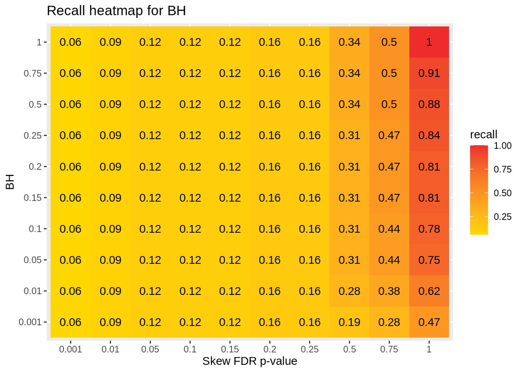

```r
ggplot(data.frame(precision.BH.dat), aes(x = as.character(FDR), y = as.character(BH), fill = recall)) +
  geom_tile() + geom_text(aes(label = round(recall, digit=2))) + xlab("Skew FDR p-value") + ylab("BH") +
  ggtitle("Recall heatmap for BH") + scale_fill_gradient(low = "gold", high = "firebrick2")
```

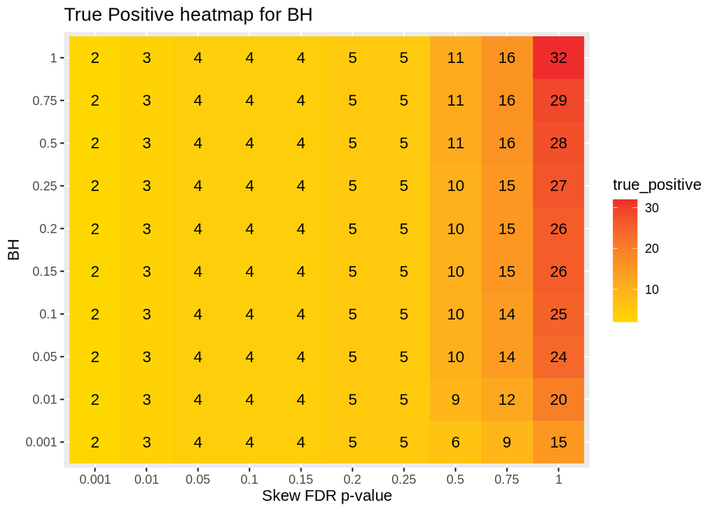

```r
ggplot(data.frame(precision.BH.dat), aes(x = as.character(FDR), y = as.character(BH), fill = true_positive)) +
  geom_tile() + geom_text(aes(label = round(true_positive, digit=2))) + xlab("Skew FDR p-value") + ylab("BH") +
  ggtitle("True Positive heatmap for BH") + scale_fill_gradient(low = "gold", high = "firebrick2")
```

Heat map for BF p-values

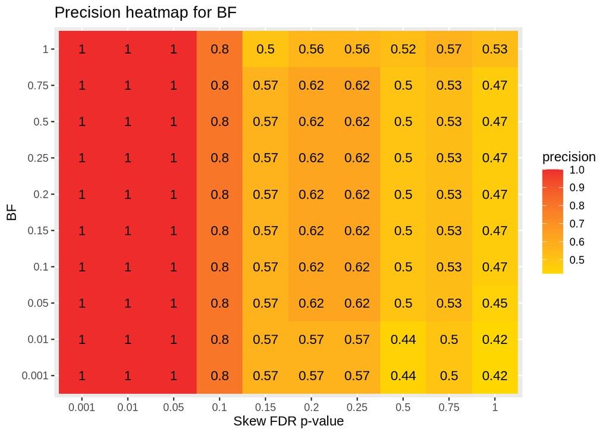

```r
BF_seq <-c(0.001, 0.01, 0.05, 0.1, 0.15, 0.2, 0.25, 0.5, 0.75, 1)
FDR_seq <-c(0.001, 0.01, 0.05, 0.1, 0.15, 0.2, 0.25, 0.5, 0.75, 1)
precision.BF.dat <- NULL
for( i in FDR_seq){
  for(j in BF_seq){
   mpra_subset <- subset(mpra, select=c(Skew.logFDR,LogSkew,max_abs_fc,max.logPadj_BH,max.logPadj_BF,max_pics)) # subset the mpra to only the columns we want.
   all_true <- nrow(subset(mpra_subset, max_pics>=0.5)) #all true in that they are all likely causal according to statistical fine-mapping. This measurement is the true positives and false negatives (which are truely positive). All true goes into the denominator of precision.
   mpra_subset$SkewFDR<- 10^-mpra_subset$Skew.logFDR # undo the negative log transformation of the Skew log p-values and create the column SkewFDR
   mpra_subset$BF<- 10^-mpra_subset$max.logPadj_BF # undo the log transformation of log 2 fold change to create a column called BF
   true_positive <- nrow(subset(mpra_subset, SkewFDR <= i & BF <= j & max_pics>=0.5)) # This variable are the true positives. They are emVars which meet the specific requirements of each variable and are positive pics values (meaning they are truly significant). This is in the numerator in both precision and recall.
   false_positive <- nrow(subset(mpra_subset, SkewFDR <= i & BF <= j & max_pics<=0.001)) # This variable is false positives. They are the non-Emvars which meet the specific requirements of the BF and SkewFDR and have the poor pics values. This is part of the denominator in precision.
   # sampled_false_positive<-false_positive[sample(nrow(false_positive), size=true_positive),]
   # we are not going to sample the false positives in these plots
   precision <- true_positive/(true_positive+false_positive) # Precision is calculated by True Positives / (True Positives + False Positives).
   recall <- true_positive/all_true # Recall is calculated as True Positives / (True Positives + False Negatives). All True is True Positives + False Negatives (which are actually true)
   precision.BF.dat <- rbind(precision.BF.dat, data.frame(i, j, precision, recall, all_true, true_positive, false_positive)) # makes the dataframe used for the heat map
  }
}
names(precision.BF.dat) <- c("FDR", "BF", "precision", "recall", "all_true", "true_positive", "false_positive")

ggplot(data.frame(precision.BF.dat), aes(x = as.character(FDR), y = as.character(BF), fill = precision)) +
  geom_tile() + geom_text(aes(label = round(precision, digit=2))) + xlab("Skew FDR p-value") + ylab("BF") +
  ggtitle("Precision heatmap for BF") + scale_fill_gradient(low = "gold", high = "firebrick2")
```

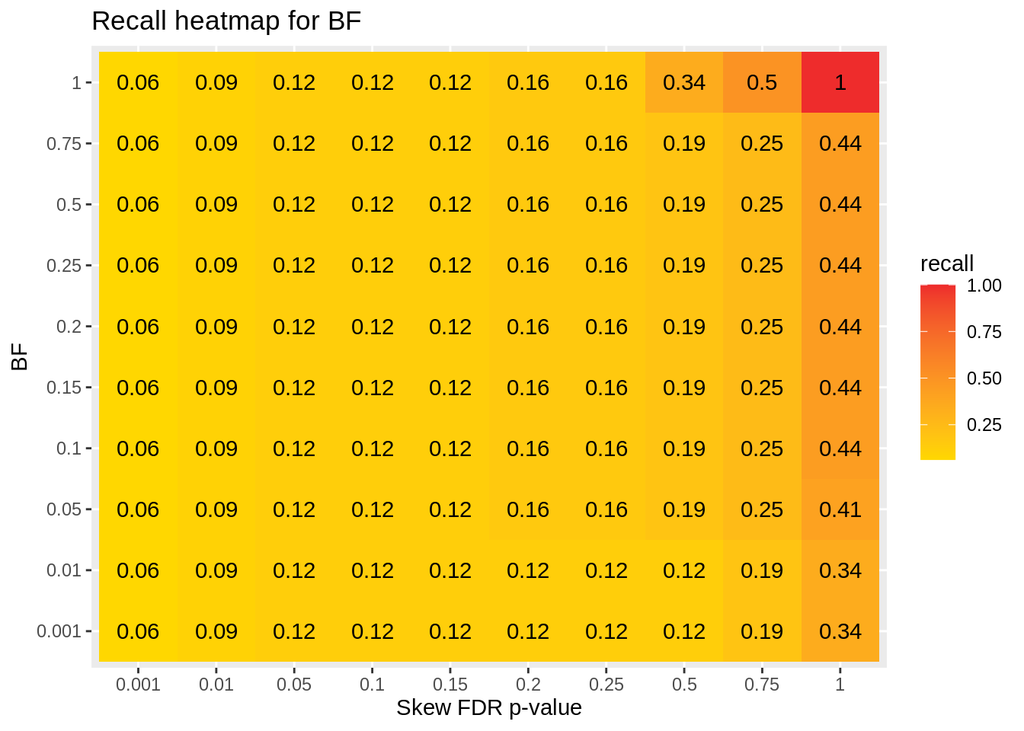

```r
ggplot(data.frame(precision.BF.dat), aes(x = as.character(FDR), y = as.character(BF), fill = recall)) +
  geom_tile() + geom_text(aes(label = round(recall, digit=2))) + xlab("Skew FDR p-value") + ylab("BF") +
  ggtitle("Recall heatmap for BF") + scale_fill_gradient(low = "gold", high = "firebrick2")
```

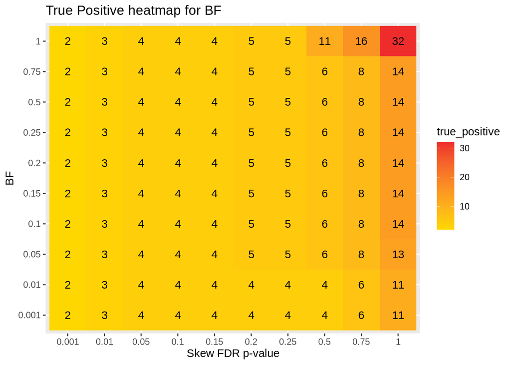

```r
ggplot(data.frame(precision.BF.dat), aes(x = as.character(FDR), y = as.character(BF), fill = true_positive)) +
  geom_tile() + geom_text(aes(label = round(true_positive, digit=2))) + xlab("Skew FDR p-value") + ylab("BF") +
  ggtitle("True Positive heatmap for BF") + scale_fill_gradient(low = "gold", high = "firebrick2")
```